# dbForge Schema Compare for MariaDB & MySQL

[**dbForge Schema Compare**](https://www.devart.com/dbforge/mysql/schemacompare/) is an efficient solution that allows for the comparison of the MariaDB database structure. With this tool, you can easily find the differences in MariaDB database schemas.

## Schema Compare Tool Key features:

### 1.Mariadb & MySQL Schema Synchronization

Update MariaDB schemas by generating accurate synchronization scripts

Preview sync scripts for any schema objects

Customize the synchronization output with various options

Get warnings on possible errors while synchronization

Sync asynchronous structure

[figure not shown]

### 2. MariaDB Backup and Restore

Enjoy the advantages of MariaDB backup and restore Wizards

Have a full or partial backup

Restore database and schedule backups with a command-line interface

Support for databases over 2Gb

[figure not shown]

### 3. Scripts Folder Comparison

Choose any connection and script folder stored locally with the new Data Comparison Wizard

View the comparison process results in a data grid

[figure not shown]

### 4. Routine Tasks Automation

Sync and compare database schemas with command-line support

Use the Windows Scheduler to automate the sync processes

Run synchronization and schema comparison tasks with command-line execution files

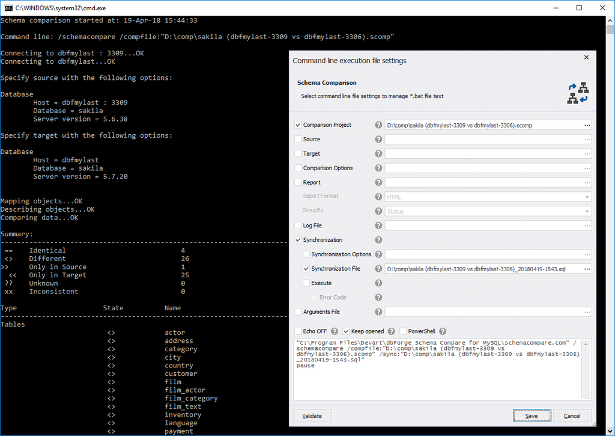

### 5. Broad Compatibility

MariaDB server versions 5.5-10.6

All MariaDB instances set up on Windows, Linux, FreeBSD, etc.

Various cloud services: Amazon RDS, Amazon Aurora, Google Cloud, Oracle MySQL Cloud, Alibaba Cloud

Security connections: Secure Socket Layer (SSL), Secure Shell (SSH), HTTP Tunneling, PAM Percona

[figure not shown]

### 6. Supported Schema Objects

[figure not shown]

### 7. Database Structure Comparison Configuration

Filter the types of objects before the comparison

Dismiss particular table options while comparing

Use the Schema Comparison Wizard for switching between the Target and Source databases

[figure not shown]

### 8. Comparison Results Analysis

Sort and filter the compared objects

Get a clear view of MariaDB and MySQL schema diffs in the grid.

Manage groups of compared objects

[figure not shown]

### 9. Comparison Results Export

Generate comparison results reports in HTML, Excel XML, XML for Excel

Include specifically selected objects in your comparison report

[figure not shown]

Download a free 30-day trial of dbForge MariaDB and MySQL Schema Compare [here](https://www.devart.com/dbforge/mysql/schemacompare/download.html).

[Documentation](https://docs.devart.com/schema-compare-for-mysql/)

| Version | Introduced |
| --- | --- |
| dbForge Schema Compare 5.0 | MariaDB 10.5 |
| dbForge Schema Compare 4.4 | MariaDB 10.4 |
| dbForge Schema Compare 4.3 | MariaDB 10.3 |
| dbForge Schema Compare 4.2 | MariaDB 10.2, MariaDB 10.1 |
| dbForge Schema Compare 3.1 | MariaDB 10.0, MariaDB 5.5 |

Content reproduced on this site is the property of its respective owners, and this content is not reviewed in advance by MariaDB. The views, information and opinions expressed by this content do not necessarily represent those of MariaDB or any other party.